# Final Project - Excel version

## Load World Happiness Report 2023

= Csv.Document(File.Contents(“C:Files.csv”),[Delimiter=“,”, Columns=19, Encoding=1252, QuoteStyle=QuoteStyle.None])

### Removed columns not used in analysis

= Table.RemoveColumns(#“Changed Type”,{“Standard error of ladder score”, “upperwhisker”, “lowerwhisker”, “Perceptions of corruption”, “Ladder score in Dystopia”, “Explained by: Log GDP per capita”, “Explained by: Social support”, “Explained by: Healthy life expectancy”, “Explained by: Freedom to make life choices”, “Explained by: Generosity”, “Explained by: Perceptions of corruption”, “Dystopia + residual”})

### Renamed columns for more intuitive understanding

= Table.RenameColumns(#“Removed columns not used in analysis”,{{“Country name”, “country_name”}, {“Ladder score”, “happiness_score”}, {“Logged GDP per capita”, “gdp_wellbeing”}, {“Social support”, “social_support”}, {“Healthy life expectancy”, “life_exp”}, {“Freedom to make life choices”, “freedom”}, {“Generosity”, “generosity”}})

Cleaned table:

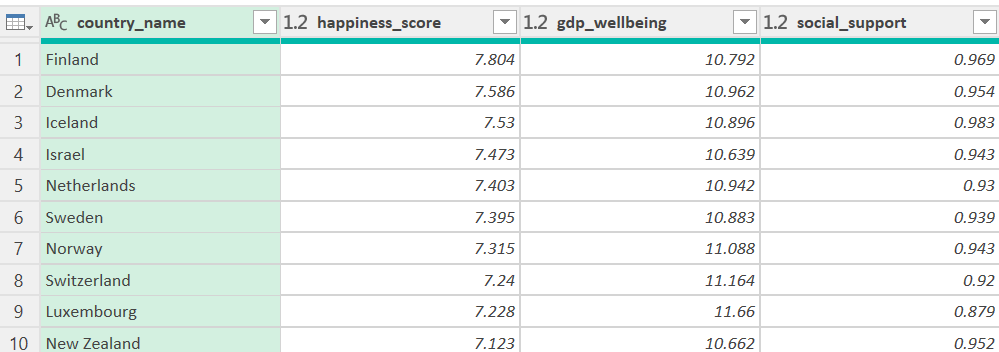

Full pipeline:

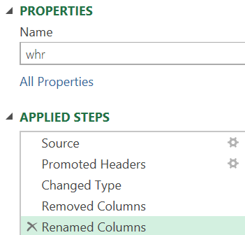

## Import Dataset 2 - Spotify Global Top 50 Song Data (Kaggle)

###Removed columns not used in analysis

= Table.RemoveColumns(#“Changed Type”,{“spotify_id”, “daily_rank”, “daily_movement”, “weekly_movement”, “snapshot_date”, “popularity”, “is_explicit”, “duration_ms”, “album_name”, “album_release_date”, “key”, “mode”, “speechiness”, “acousticness”, “instrumentalness”, “liveness”, “time_signature”})

### Renamed columns for matching

= Table.RenameColumns(#“Removed Columns”,{{“name”, “title”}})

### Split artist column by ‘,’ delimiter

= Table.SplitColumn(#“Renamed Columns”, “artists”, Splitter.SplitTextByEachDelimiter({“,”}, QuoteStyle.Csv, false), {“artists.1”, “artists.2”})

= Table.SplitColumn(#“Renamed Columns”, “artists”, Splitter.SplitTextByEachDelimiter({“,”}, QuoteStyle.Csv, false), {“artists.1”, “artists.2”})

### Renamed remaining artist column

= Table.RenameColumns(#“Filtered Rows2”,{{“artists.1”, “artist”}})

Cleaned Dataset:

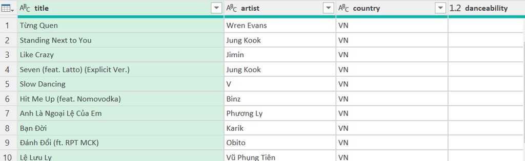

Pipeline:

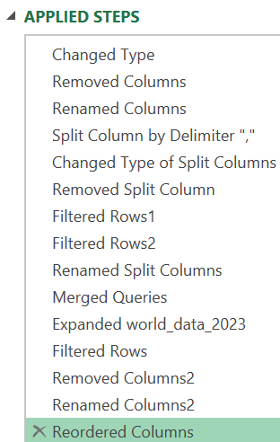

## Import & Wrangle Dataset 3 - World Data 2023 (Kaggle)

= Csv.Document(File.Contents(“C:Files_data_2023.csv”),[Delimiter=“,”, Columns=35, Encoding=65001, QuoteStyle=QuoteStyle.Csv])

### Removed all columns except Abbreviation and Country

= Table.RemoveColumns(#“Changed Type”,{“Density#(lf)(P/Km2)”, “Agricultural Land( %)”, “Land Area(Km2)”, “Armed Forces size”, “Birth Rate”, “Calling Code”, “Capital/Major City”, “Co2-Emissions”, “CPI”, “CPI Change (%)”, “Currency-Code”, “Fertility Rate”, “Forested Area (%)”, “Gasoline Price”, “GDP”, “Gross primary education enrollment (%)”, “Gross tertiary education enrollment (%)”, “Infant mortality”, “Largest city”, “Life expectancy”, “Maternal mortality ratio”, “Minimum wage”, “Official language”, “Out of pocket health expenditure”, “Physicians per thousand”, “Population”, “Population: Labor force participation (%)”, “Tax revenue (%)”, “Total tax rate”, “Unemployment rate”, “Urban_population”, “Latitude”, “Longitude”})

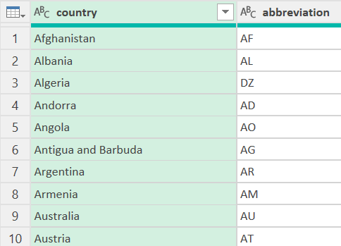

Pipeline:

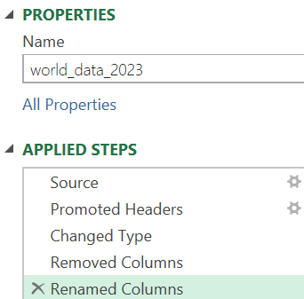

## Import & Wrangle Dataset 4 - Weekly Charts of October 16, 2025 (Kworb)

### 4.1 New Zealand Dataset

= Csv.Document(File.Contents(“C:Files\10_16_25_new_zealand.csv”), [Delimiter=“,”, Columns=9, Encoding=65001, QuoteStyle=QuoteStyle.None])

### Kept only ‘Artist and Title’

= Table.RemoveColumns(#“Changed Type”,{“Pos”, “P+”, “Wks”, “Pk”, “(x?)”, “Streams”, “Streams+”, “Total”})

### Split by ‘-’ Delimiter

= Table.SplitColumn(#“Kept only”“Artist and Title”““,”Artist and Title”, Splitter.SplitTextByEachDelimiter({” - “}, QuoteStyle.Csv, false), {”Artist and Title.1”, “Artist and Title.2”})

### Renamed split columns

= Table.RenameColumns(#“Changed Type1”,{{“Artist and Title.1”, “artist”}, {“Artist and Title.2”, “title”}})

### Lowercased columns for more accurate matching

= Table.TransformColumns(#“Renamed Columns”,{{“artist”, Text.Lower, type text}, {“title”, Text.Lower, type text}})

### Split column by ‘,’ for matching to Spotify datasets

= Table.SplitColumn(#“Lowercased Text”, “artist”, Splitter.SplitTextByEachDelimiter({“,”}, QuoteStyle.Csv, false), {“artist.1”, “artist.2”})

### Removed split artist column

= Table.RemoveColumns(#“Split Column by Delimiter”“,”““,{”artist.2”})

### Renamed remaining artist column

= Table.RenameColumns(#“Removed second artist column”,{{“artist.1”, “artist”}})

#### Cleaned Dataset

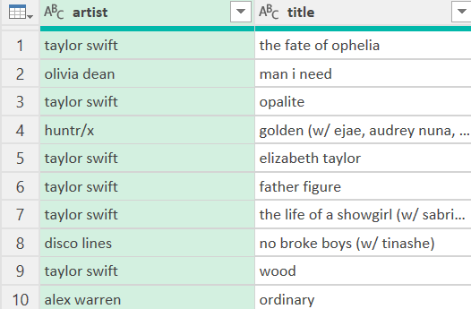

#### Pipeline

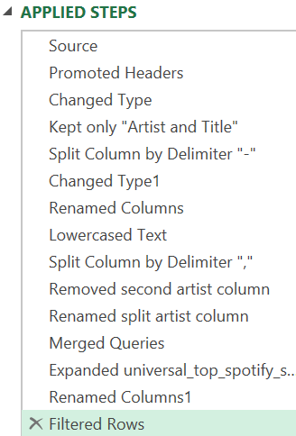

#### Pipeline

[figure not shown]

### 4.2 South Korea Dataset

= Csv.Document(File.Contents(“C:Files\10_16_25_korea.csv”),[Delimiter=“,”, Columns=9, Encoding=65001, QuoteStyle=QuoteStyle.None])

### Kept only ‘Artist and Title’

= Table.RemoveColumns(#“Changed Type”,{“Pos”, “P+”, “Wks”, “Pk”, “(x?)”, “Streams”, “Streams+”, “Total”})

### Split by ‘-’ Delimiter

= Table.SplitColumn(#“Kept only”“Artist and Title”““,”Artist and Title”, Splitter.SplitTextByEachDelimiter({” - “}, QuoteStyle.Csv, false), {”Artist and Title.1”, “Artist and Title.2”})

### Renamed split columns

= Table.RenameColumns(#“Changed Type1”,{{“Artist and Title.1”, “artist”}, {“Artist and Title.2”, “title”}})

### Lowercased columns for more accurate matching

= Table.TransformColumns(#“Renamed Columns”,{{“artist”, Text.Lower, type text}, {“title”, Text.Lower, type text}})

### Split column by ‘,’ for matching to Spotify datasets

= Table.SplitColumn(#“Lowercased Text”, “artist”, Splitter.SplitTextByEachDelimiter({“,”}, QuoteStyle.Csv, false), {“artist.1”, “artist.2”})

### Removed split artist column

= Table.RemoveColumns(#“Split Column by Delimiter”“,”““,{”artist.2”})

### Renamed remaining artist column

= Table.RenameColumns(#“Removed second artist column”,{{“artist.1”, “artist”}})

#### Cleaned Dataset

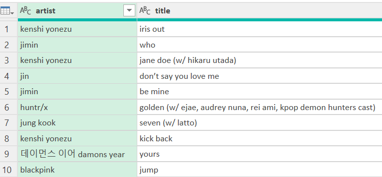

#### Pipeline

[figure not shown]

### 4.3 USA Dataset

= Csv.Document(File.Contents(“C:Files\10_16_25_usa.csv”),[Delimiter=“,”, Columns=9, Encoding=65001, QuoteStyle=QuoteStyle.None])

### Kept only ‘Artist and Title’

= Table.RemoveColumns(#“Changed Type”,{“Pos”, “P+”, “Wks”, “Pk”, “(x?)”, “Streams”, “Streams+”, “Total”})

### Split by ‘-’ Delimiter

= Table.SplitColumn(#“Kept only”“Artist and Title”““,”Artist and Title”, Splitter.SplitTextByEachDelimiter({” - “}, QuoteStyle.Csv, false), {”Artist and Title.1”, “Artist and Title.2”})

### Renamed split columns

= Table.RenameColumns(#“Changed Type1”,{{“Artist and Title.1”, “artist”}, {“Artist and Title.2”, “title”}})

### Lowercased columns for more accurate matching

= Table.TransformColumns(#“Renamed Columns”,{{“artist”, Text.Lower, type text}, {“title”, Text.Lower, type text}})

### Split column by ‘,’ for matching to Spotify datasets

= Table.SplitColumn(#“Lowercased Text”, “artist”, Splitter.SplitTextByEachDelimiter({“,”}, QuoteStyle.Csv, false), {“artist.1”, “artist.2”})

### Removed split artist column

= Table.RemoveColumns(#“Split Column by Delimiter”“,”““,{”artist.2”})

### Renamed remaining artist column

= Table.RenameColumns(#“Removed second artist column”,{{“artist.1”, “artist”}})

#### Cleaned Dataset

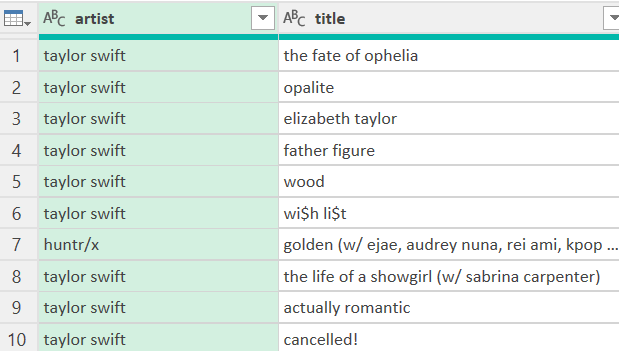

#### Pipeline

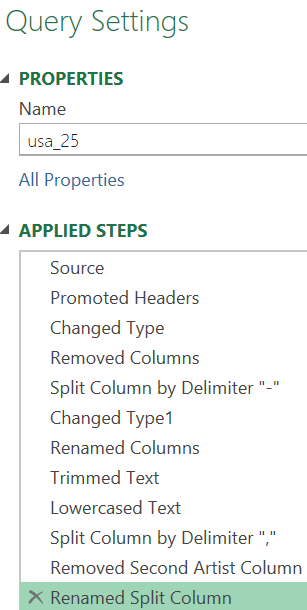

## Import Dataset 5 - Spotify Global Top 50 Song Data 2025 (Kaggle)

###Removed columns not used in analysis

= Table.RemoveColumns(#“Changed Type”,{“spotify_id”, “daily_rank”, “daily_movement”, “weekly_movement”, “snapshot_date”, “popularity”, “is_explicit”, “duration_ms”, “album_name”, “album_release_date”, “key”, “mode”, “speechiness”, “acousticness”, “instrumentalness”, “liveness”, “time_signature”})

### Renamed columns for matching

= Table.RenameColumns(#“Removed Columns”,{{“name”, “title”}})

### Split artist column by ‘,’ delimiter

= Table.SplitColumn(#“Renamed Columns”, “artists”, Splitter.SplitTextByEachDelimiter({“,”}, QuoteStyle.Csv, false), {“artists.1”, “artists.2”})

= Table.SplitColumn(#“Renamed Columns”, “artists”, Splitter.SplitTextByEachDelimiter({“,”}, QuoteStyle.Csv, false), {“artists.1”, “artists.2”})

### Renamed remaining artist column

= Table.RenameColumns(#“Filtered Rows2”,{{“artists.1”, “artist”}})

Cleaned Dataset:

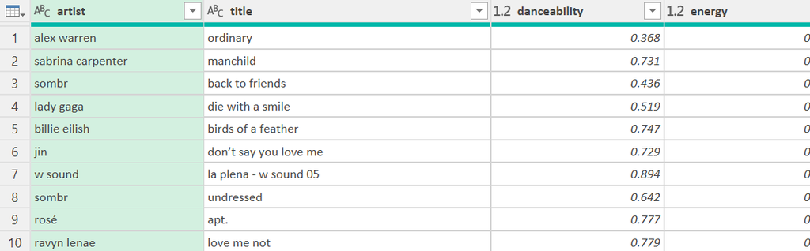

Pipeline

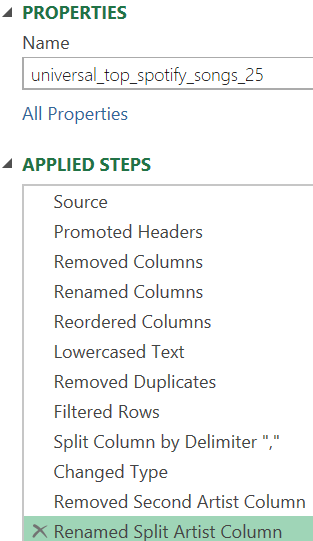

## Combine dataset 2 and 3

#### Replace country abbreviation with its full name; Match spotify’s country abbreviation with abbreviation table’s abbreviation

= Table.NestedJoin(#“Renamed Split Columns”, {“country”}, world_data_2023, {“abbreviation”}, “world_data_2023”, JoinKind.LeftOuter)

#### Remove any unmatched rows

= Table.SelectRows(#“Expanded world_data_2023”, each [world_data_2023.country] <> null and [world_data_2023.country] <> ““)

#### Put country column first

= Table.ReorderColumns(#“Renamed Columns2”,{“country”, “title”, “artist”, “danceability”, “energy”, “loudness”, “tempo”})

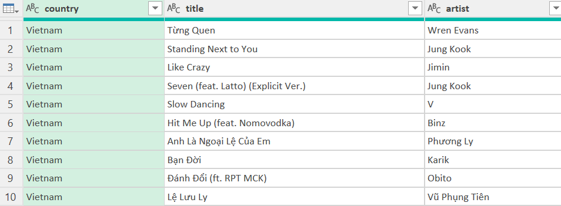

#### Calculate averages of spotify_global_2023_matched dataset by Country

= Table.Group(#“Reordered Columns”, {“country”}, {{“danceability_avg”, each List.Average([danceability]), type nullable number}, {“energy_avg”, each List.Average([energy]), type nullable number}}, {“valence_avg”, each List.Average([valence]), type nullable number}}, {“loudness_avg”, each List.Average([loudness]), type nullable number}}, {“tempo_avg”, each List.Average([tempo]), type nullable number}})

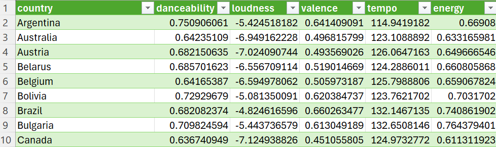

## Join Dataset 5 to Each Country’s Dataset for 2025 Analysis

### New Zealand Dataset

#### Join New Zealand dataframe and updated Spotify dataframe

#### Left join to keep all the rows of left dataframe

= Table.NestedJoin(#“Renamed split artist column”, {“artist”, “title”}, universal_top_spotify_songs_25, {“artist”, “title”}, “universal_top_spotify_songs_25”, JoinKind.LeftOuter)

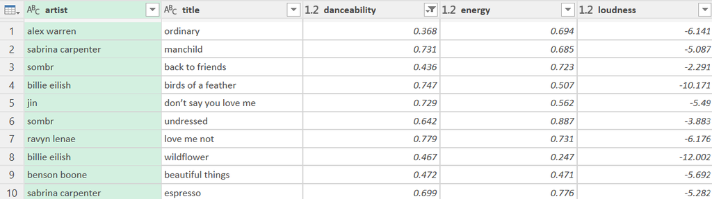

#### Calculate average for each column, will be used later for 2023 and 2025 comparison

Average functions used in output table in Excel

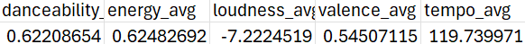

#### Join Korea dataframe and updated Spotify dataframe

#### Left join to keep all the rows of left dataframe

= Table.NestedJoin(#“Renamed split artist column”, {“artist”, “title”}, universal_top_spotify_songs_25, {“artist”, “title”}, “universal_top_spotify_songs_25”, JoinKind.LeftOuter)

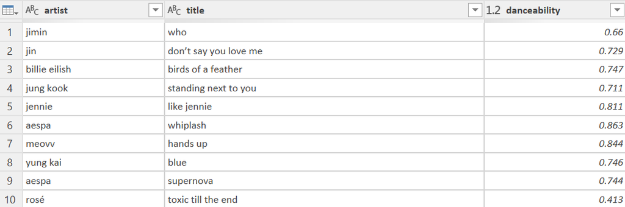

#### Calculate average for each column, will be used later for 2023 and 2025 comparison

Average functions used within output table in Excel:

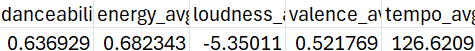

#### Join USA dataframe and updated Spotify dataframe

#### Left join to keep all the rows of left dataframe

= Table.NestedJoin(#“Renamed split artist column”, {“artist”, “title”}, universal_top_spotify_songs_25, {“artist”, “title”}, “universal_top_spotify_songs_25”, JoinKind.LeftOuter)

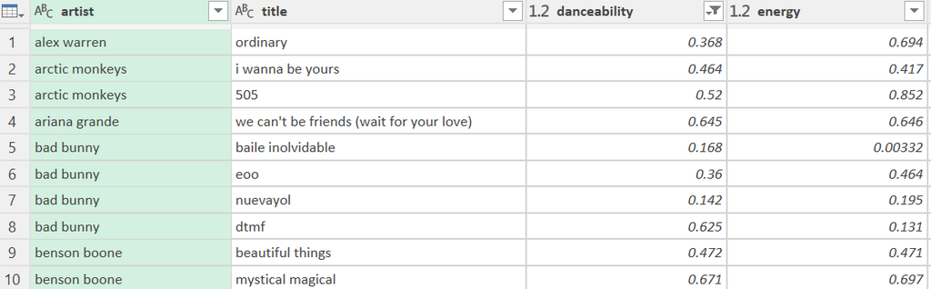

#### Calculate average for each column, will be used later for 2023 and 2025 comparison

Avg calculated using functions on output table in Excel:

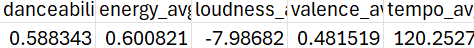

## Correlation Studies

#### Combine aggregated Spotify dataset with happiness report

= Table.NestedJoin(#“Reordered Columns”, {“country”}, whr, {“country_name”}, “whr”, JoinKind.LeftOuter)

#### Drop any countries with no happiness score

= Table.SelectRows(#“Renamed Columns1”, each [happiness_score] <> null and [happiness_score] <> ““)

= Table.SelectRows(#“Filtered Rows3”, each [country] <> null and [country] <> ““)

This was outputted to table “Correlation Study.”

#### Calculate Matrix in Excel

Formulas repeated for Correlation Study, e.g., “=CORREL(‘Correlation Study’!A2:A100, ‘Correlation Study’!A2:A100)”, =CORREL(‘Correlation Study’!A2:A100, ‘Correlation Study’!B2:B100)“, etc.

Conditional formatting was used to create heatmap.

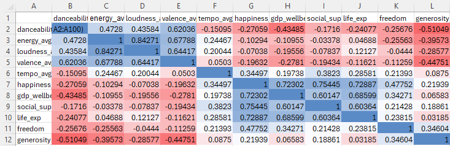

#### Melt matrix

= Table.UnpivotOtherColumns(#“Changed Type”, {“Column1”}, “Attribute”, “Value”)

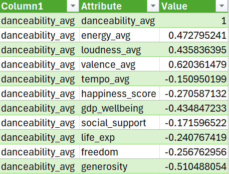